# 交易类因子

## 6、处置效应因子DISP

```r
tsfr <- tsfrs_raw$DISP_
mtsfr <- factor_refine_MF(tsfr,refinePars)
```

```
## Function getTSF: getting the factorscore ....
## Function getTSF: getting the factorscore ....
## Function getMultiFactor: getting the score of factor ln_cap ....
```

```r
mtsfrrefine <- rbind(mtsfrrefine,data.frame(mtsfr,fname='DISP_'))
```

因子NA比例

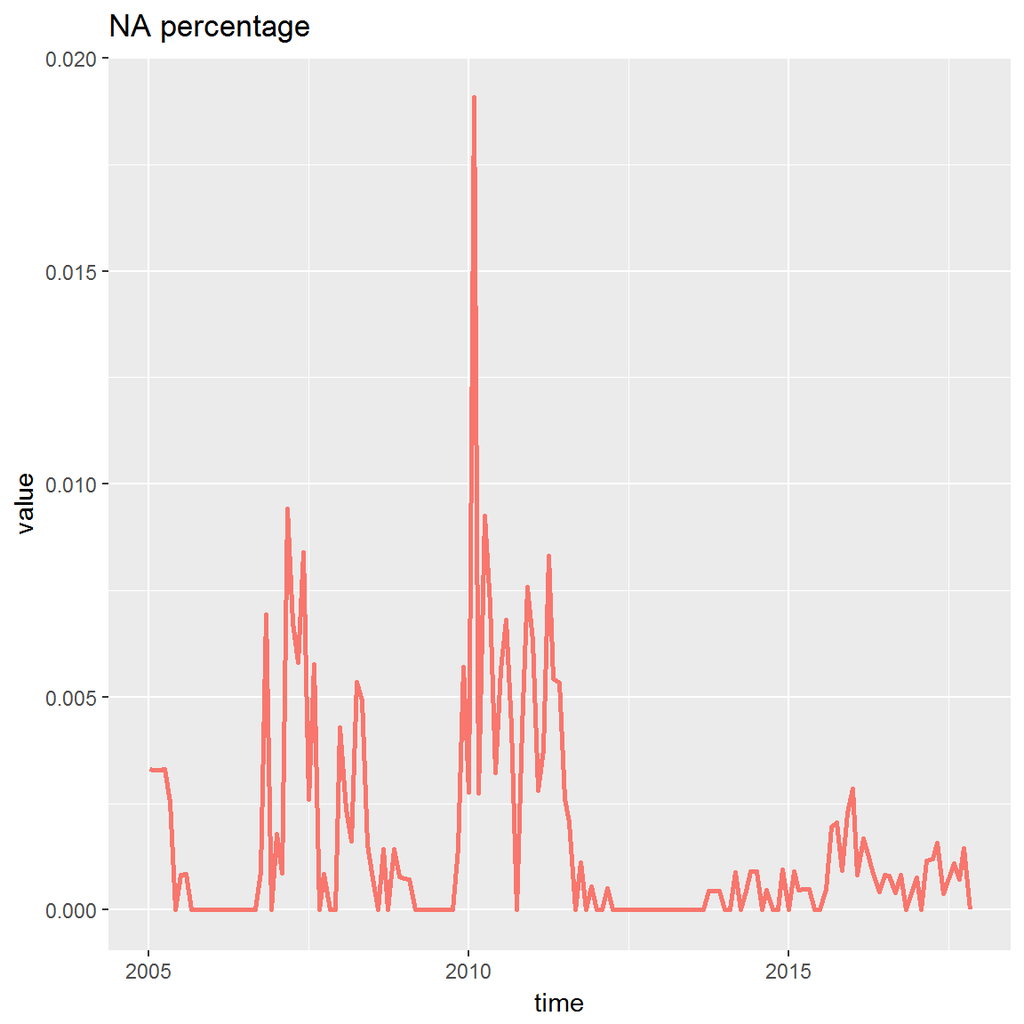

```r
chart.Fct_NA(tsfr)
```

因子原始得分直方图

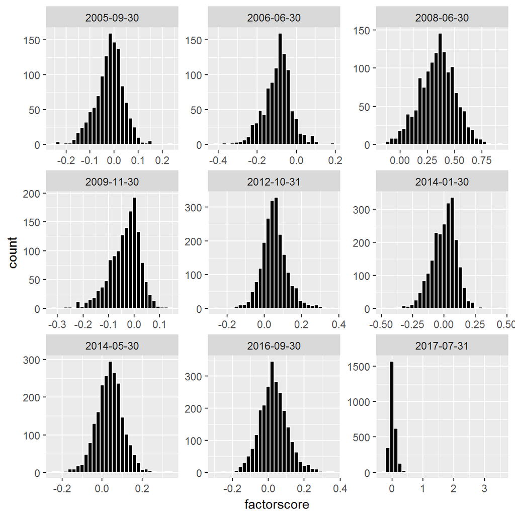

```r
chart.Fct_hist(tsfr,9)
```

不同refine方式下因子得分分布直方图

```
## The guessed factorNames are: scale,scale_ind,scale_indfct,reg_indfct.
```

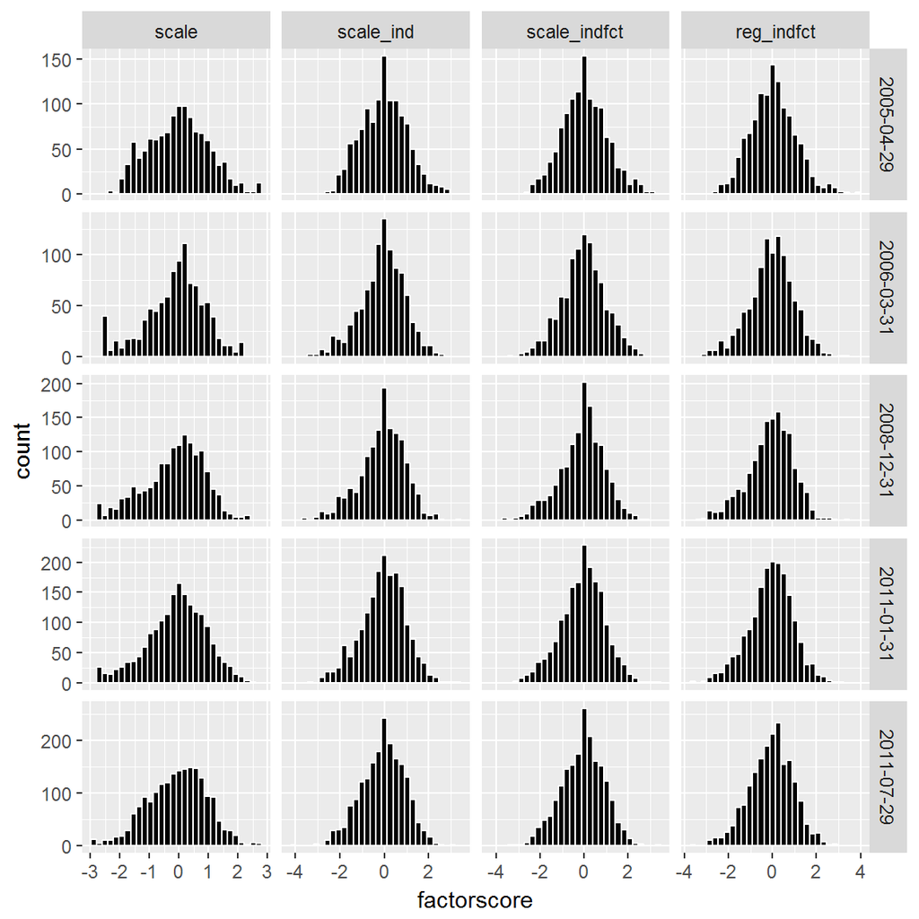

```r
MF.chart.Fct_hist(mtsfr,5)
```

不同refine方式下因子得分统计表

```r
kable(MF.table.Fct_descr(mtsfr,5),digits = 2)
```

```
## The guessed factorNames are: scale,scale_ind,scale_indfct,reg_indfct.
```

| date | fname | Obs | NAs | min | max | mean | median | sd | skewness | kurtosis |
| --- | --- | --- | --- | --- | --- | --- | --- | --- | --- | --- |
| 2005-05-31 | scale | 1228 | 0 | -2.39 | 2.72 | 0.05 | 0 | 1.00 | 0.32 | -0.13 |
| 2005-05-31 | scale_ind | 1228 | 0 | -2.50 | 3.40 | 0.04 | 0 | 1.00 | 0.30 | 0.02 |
| 2005-05-31 | scale_indfct | 1228 | 0 | -2.62 | 3.40 | 0.04 | 0 | 0.99 | 0.30 | 0.00 |
| 2005-05-31 | reg_indfct | 1228 | 0 | -2.57 | 3.23 | 0.05 | 0 | 1.00 | 0.30 | 0.07 |
| 2005-06-30 | scale | 1208 | 0 | -2.53 | 2.62 | 0.06 | 0 | 1.00 | 0.40 | 0.04 |
| 2005-06-30 | scale_ind | 1208 | 0 | -2.54 | 3.28 | 0.04 | 0 | 0.99 | 0.37 | 0.06 |
| 2005-06-30 | scale_indfct | 1208 | 0 | -2.75 | 3.28 | 0.08 | 0 | 0.99 | 0.36 | 0.09 |
| 2005-06-30 | reg_indfct | 1208 | 0 | -2.77 | 3.19 | 0.09 | 0 | 1.00 | 0.43 | 0.19 |
| 2009-04-30 | scale | 1364 | 0 | -2.58 | 2.52 | -0.04 | 0 | 1.00 | -0.18 | -0.10 |
| 2009-04-30 | scale_ind | 1364 | 0 | -3.57 | 2.85 | -0.05 | 0 | 0.99 | -0.26 | 0.03 |
| 2009-04-30 | scale_indfct | 1364 | 0 | -3.39 | 3.05 | -0.05 | 0 | 0.99 | -0.20 | -0.02 |
| 2009-04-30 | reg_indfct | 1364 | 0 | -3.76 | 2.76 | -0.04 | 0 | 1.00 | -0.24 | 0.12 |
| 2010-05-31 | scale | 1556 | 0 | -2.75 | 2.62 | -0.11 | 0 | 1.00 | -0.39 | -0.30 |
| 2010-05-31 | scale_ind | 1556 | 0 | -3.70 | 2.91 | -0.11 | 0 | 0.99 | -0.36 | 0.01 |
| 2010-05-31 | scale_indfct | 1556 | 0 | -3.53 | 3.15 | -0.07 | 0 | 0.99 | -0.34 | 0.25 |
| 2010-05-31 | reg_indfct | 1556 | 0 | -3.44 | 3.10 | -0.08 | 0 | 1.00 | -0.38 | 0.06 |
| 2015-04-30 | scale | 2074 | 0 | -2.52 | 2.31 | -0.14 | 0 | 1.00 | -0.46 | -0.03 |
| 2015-04-30 | scale_ind | 2074 | 0 | -3.84 | 2.74 | -0.13 | 0 | 1.00 | -0.44 | 0.06 |
| 2015-04-30 | scale_indfct | 2074 | 0 | -3.61 | 2.74 | -0.11 | 0 | 0.99 | -0.38 | 0.05 |
| 2015-04-30 | reg_indfct | 2074 | 0 | -2.92 | 2.64 | -0.12 | 0 | 1.00 | -0.39 | -0.04 |

不同refine方式下因子IC图

```
## The guessed factorNames are: scale,scale_ind,scale_indfct,reg_indfct.
```

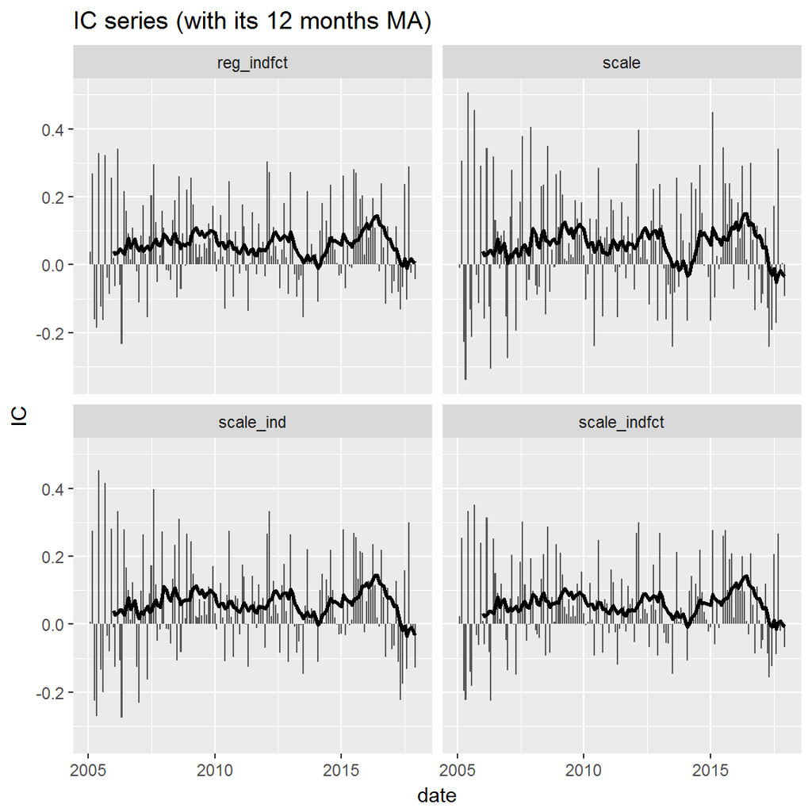

```r
MF.chart.IC(mTSFR = mtsfr,facet_by = 'fname')
```

不同refine方式下因子分组多空收益图

```
## The guessed factorNames are: scale,scale_ind,scale_indfct,reg_indfct.
```

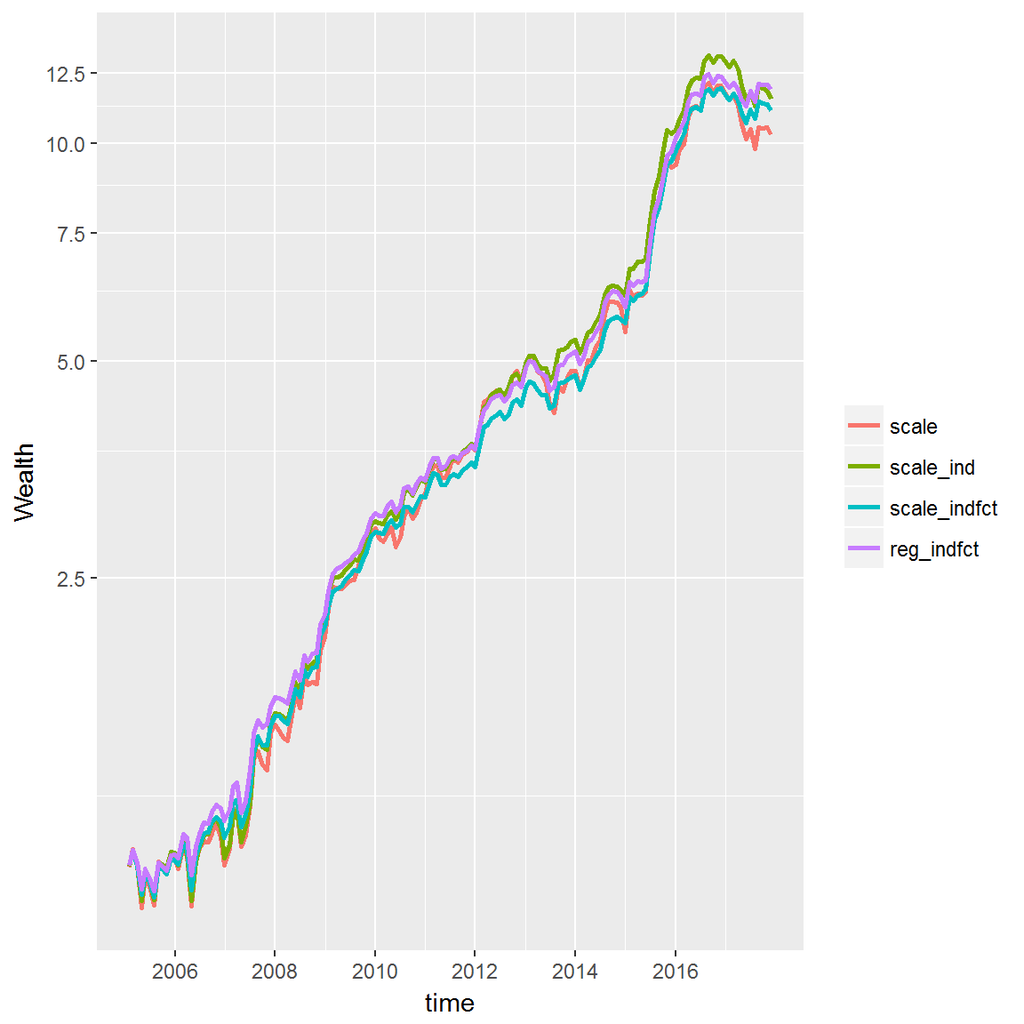

```r
MF.chart.Ngroup.spread(mTSFR = mtsfr, N = 5)
```

不同refine方式下因子分组多空相对收益图

```
## The guessed factorNames are: scale,scale_ind,scale_indfct,reg_indfct.
```

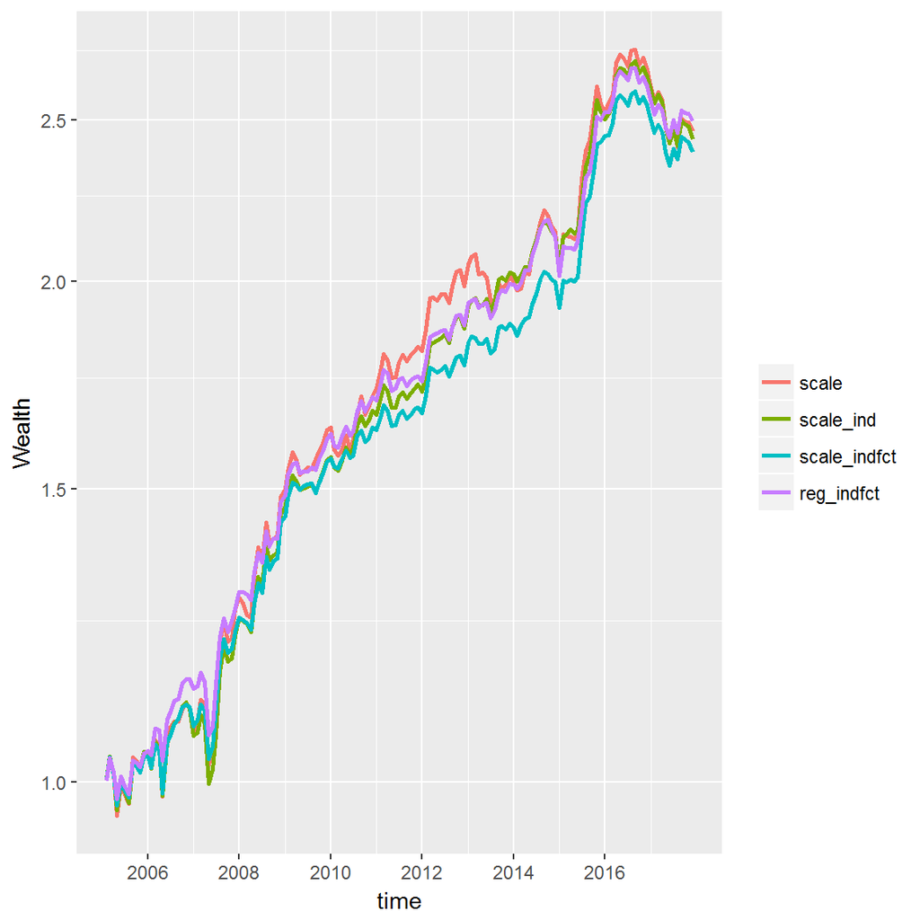

```r
MF.chart.Ngroup.spread(mTSFR = mtsfr, N = 5,rtn_type = "long-univ")
```

不同refine方式下因子IC和分组收益统计表

```r
table_ <- MC.table.ICandNgroup(mTSF2TSFs(mtsfr), N = 5)
```

```
## The guessed factorNames are: scale,scale_ind,scale_indfct,reg_indfct.
```

```r
kable(table_,digits = 2)
```

|  | IC_mean | IC_std | IC_IR | IC_t | IC_p | IC_hitRatio | IC_annu | Annualized Return | Annualized StdDev | Annualized Sharpe(Rf=0%) | HitRatio | Worst Drawdown | Annualized Turnover | Annualized Return (fee cut) | Beta | Size |
| --- | --- | --- | --- | --- | --- | --- | --- | --- | --- | --- | --- | --- | --- | --- | --- | --- |
| scale | 0.06 | 0.17 | 0.33 | 4.16 | 0 | 0.62 | 0.20 | 0.20 | 0.18 | 1.08 | 0.60 | 0.19 | 7.14 | 0.20 | 0.11 | -54.96 |
| scale_ind | 0.06 | 0.14 | 0.41 | 5.11 | 0 | 0.65 | 0.20 | 0.21 | 0.16 | 1.34 | 0.66 | 0.17 | 7.22 | 0.21 | 0.11 | -34.69 |
| scale_indfct | 0.06 | 0.12 | 0.45 | 5.63 | 0 | 0.65 | 0.19 | 0.20 | 0.14 | 1.51 | 0.68 | 0.14 | 7.29 | 0.20 | 0.10 | -23.67 |
| reg_indfct | 0.06 | 0.12 | 0.47 | 5.90 | 0 | 0.66 | 0.20 | 0.21 | 0.13 | 1.57 | 0.68 | 0.12 | 7.19 | 0.21 | 0.09 | 37.89 |

```r
table_ <- data.frame(factorName="DISP_",refinePar=rownames(table_),table_,row.names = NULL,stringsAsFactors = FALSE)
tablestats <- rbind(tablestats,table_)
```

## 7、反转因子PCT

```r
tsfr <- tsfrs_raw$pct_chg_per_60_
mtsfr <- factor_refine_MF(tsfr,refinePars)
```

```
## Function getTSF: getting the factorscore ....
## Function getTSF: getting the factorscore ....
## Function getMultiFactor: getting the score of factor ln_cap ....
```

```r
mtsfrrefine <- rbind(mtsfrrefine,data.frame(mtsfr,fname='pct_chg_per_60_'))
```

因子NA比例

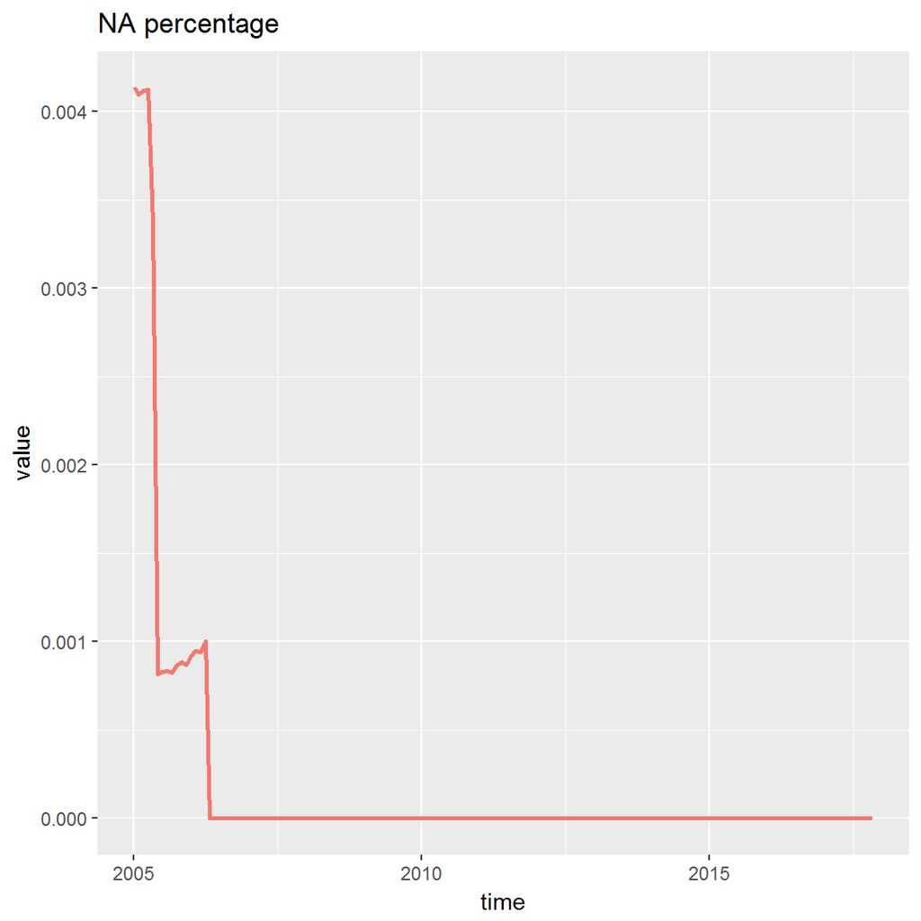

```r
chart.Fct_NA(tsfr)
```

因子原始得分直方图

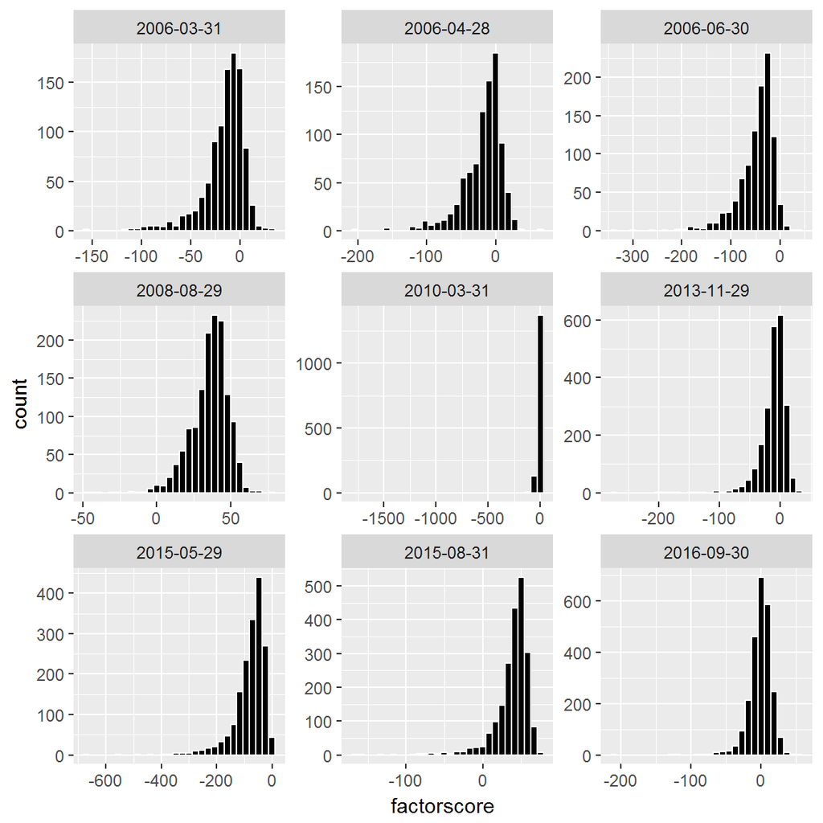

```r
chart.Fct_hist(tsfr,9)
```

不同refine方式下因子得分分布直方图

```
## The guessed factorNames are: scale,scale_ind,scale_indfct,reg_indfct.
```

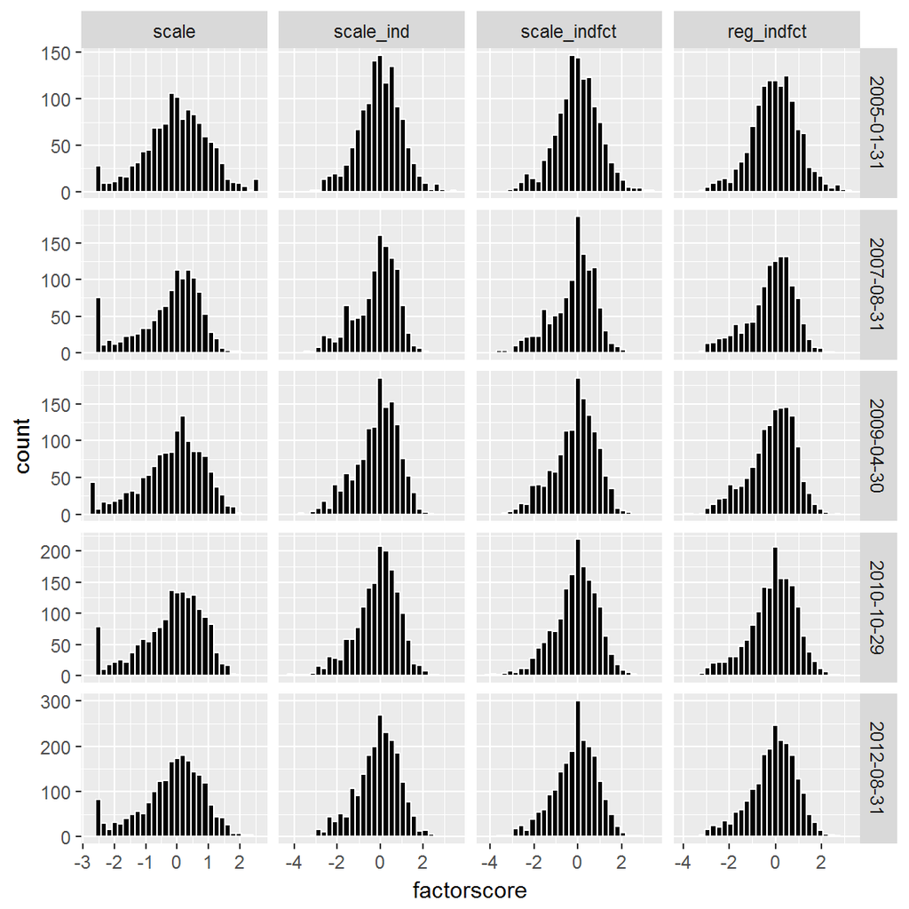

```r
MF.chart.Fct_hist(mtsfr,5)
```

不同refine方式下因子得分统计表

```r
kable(MF.table.Fct_descr(mtsfr,5),digits = 2)
```

```
## The guessed factorNames are: scale,scale_ind,scale_indfct,reg_indfct.
```

| date | fname | Obs | NAs | min | max | mean | median | sd | skewness | kurtosis |
| --- | --- | --- | --- | --- | --- | --- | --- | --- | --- | --- |
| 2009-01-23 | scale | 1383 | 0 | -2.59 | 2.40 | -0.13 | 0 | 1.00 | -0.41 | 0.14 |
| 2009-01-23 | scale_ind | 1383 | 0 | -3.68 | 2.77 | -0.09 | 0 | 0.99 | -0.43 | 0.34 |
| 2009-01-23 | scale_indfct | 1383 | 0 | -3.44 | 3.05 | -0.10 | 0 | 0.99 | -0.42 | 0.34 |
| 2009-01-23 | reg_indfct | 1383 | 0 | -3.48 | 3.05 | -0.11 | 0 | 1.00 | -0.44 | 0.40 |
| 2011-10-31 | scale | 1835 | 0 | -2.57 | 2.49 | -0.06 | 0 | 1.00 | -0.35 | 0.09 |
| 2011-10-31 | scale_ind | 1835 | 0 | -3.19 | 3.86 | -0.07 | 0 | 1.00 | -0.23 | 0.25 |
| 2011-10-31 | scale_indfct | 1835 | 0 | -3.02 | 3.21 | -0.05 | 0 | 0.99 | -0.22 | 0.22 |
| 2011-10-31 | reg_indfct | 1835 | 0 | -3.08 | 2.70 | -0.06 | 0 | 1.00 | -0.34 | 0.32 |
| 2014-12-31 | scale | 2157 | 0 | -2.57 | 1.89 | -0.26 | 0 | 1.00 | -0.88 | 0.01 |
| 2014-12-31 | scale_ind | 2157 | 0 | -4.65 | 3.67 | -0.15 | 0 | 1.00 | -0.82 | 1.22 |
| 2014-12-31 | scale_indfct | 2157 | 0 | -4.48 | 3.67 | -0.12 | 0 | 1.00 | -0.73 | 1.36 |
| 2014-12-31 | reg_indfct | 2157 | 0 | -4.04 | 2.88 | -0.12 | 0 | 1.00 | -0.82 | 1.17 |
| 2015-04-30 | scale | 2074 | 0 | -2.58 | 2.32 | -0.24 | 0 | 1.00 | -0.84 | 0.05 |
| 2015-04-30 | scale_ind | 2074 | 0 | -3.60 | 2.39 | -0.21 | 0 | 1.00 | -0.81 | 0.24 |
| 2015-04-30 | scale_indfct | 2074 | 0 | -4.50 | 2.50 | -0.19 | 0 | 0.99 | -0.76 | 0.33 |
| 2015-04-30 | reg_indfct | 2074 | 0 | -3.28 | 2.66 | -0.21 | 0 | 1.00 | -0.77 | 0.14 |
| 2016-02-29 | scale | 2398 | 0 | -2.47 | 2.22 | -0.14 | 0 | 1.00 | -0.59 | -0.05 |
| 2016-02-29 | scale_ind | 2398 | 0 | -3.54 | 2.83 | -0.12 | 0 | 1.00 | -0.60 | 0.33 |
| 2016-02-29 | scale_indfct | 2398 | 0 | -3.76 | 3.00 | -0.09 | 0 | 0.99 | -0.54 | 0.46 |
| 2016-02-29 | reg_indfct | 2398 | 0 | -3.27 | 2.72 | -0.11 | 0 | 1.00 | -0.57 | 0.25 |

不同refine方式下因子IC图

```
## The guessed factorNames are: scale,scale_ind,scale_indfct,reg_indfct.
```

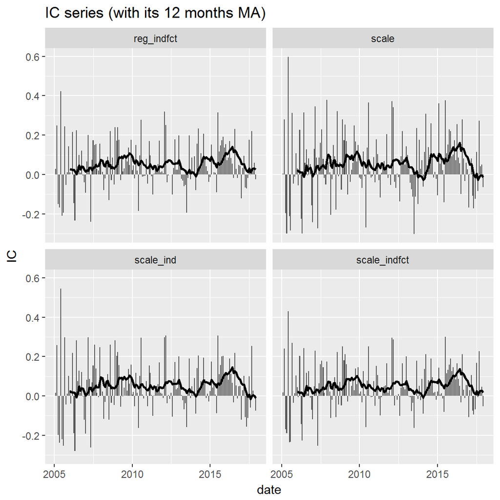

```r
MF.chart.IC(mTSFR = mtsfr,facet_by = 'fname')
```

不同refine方式下因子分组多空收益图

```
## The guessed factorNames are: scale,scale_ind,scale_indfct,reg_indfct.
```

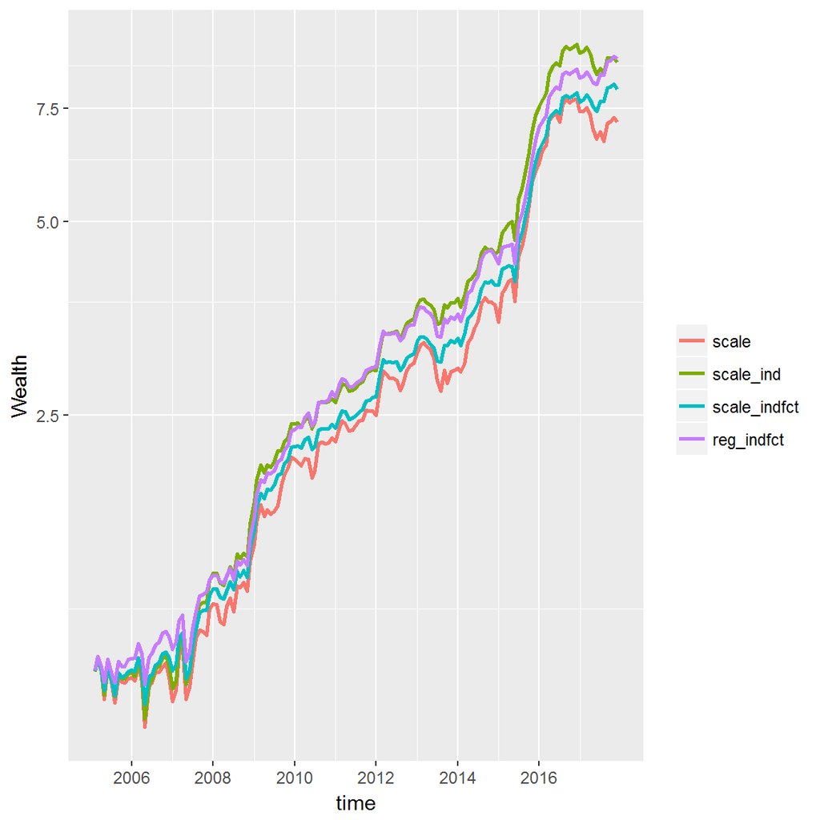

```r
MF.chart.Ngroup.spread(mTSFR = mtsfr, N = 5)
```

不同refine方式下因子分组多空相对收益图

```
## The guessed factorNames are: scale,scale_ind,scale_indfct,reg_indfct.
```

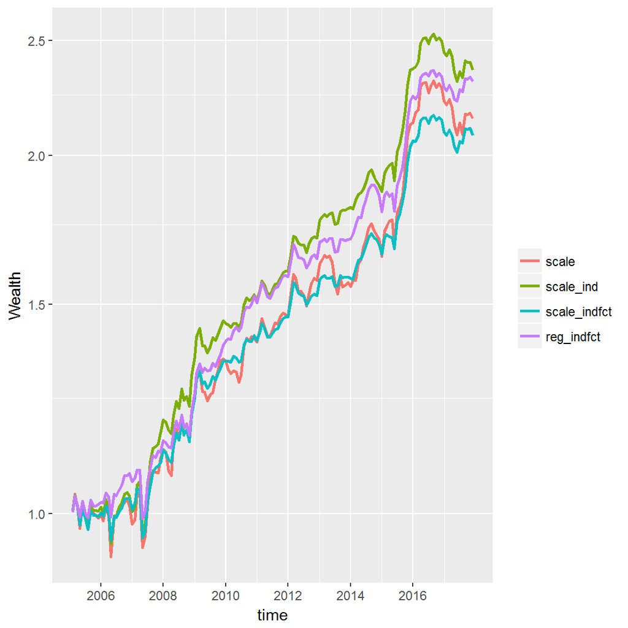

```r
MF.chart.Ngroup.spread(mTSFR = mtsfr, N = 5,rtn_type = "long-univ")
```

不同refine方式下因子IC和分组收益统计表

```r
table_ <- MC.table.ICandNgroup(mTSF2TSFs(mtsfr), N = 5)
```

```
## The guessed factorNames are: scale,scale_ind,scale_indfct,reg_indfct.
```

```r
kable(table_,digits = 2)
```

|  | IC_mean | IC_std | IC_IR | IC_t | IC_p | IC_hitRatio | IC_annu | Annualized Return | Annualized StdDev | Annualized Sharpe(Rf=0%) | HitRatio | Worst Drawdown | Annualized Turnover | Annualized Return (fee cut) | Beta | Size |
| --- | --- | --- | --- | --- | --- | --- | --- | --- | --- | --- | --- | --- | --- | --- | --- | --- |
| scale | 0.05 | 0.16 | 0.33 | 4.05 | 0 | 0.63 | 0.18 | 0.16 | 0.18 | 0.93 | 0.61 | 0.22 | 6.23 | 0.16 | 0.07 | -18.17 |
| scale_ind | 0.05 | 0.13 | 0.39 | 4.83 | 0 | 0.70 | 0.18 | 0.18 | 0.15 | 1.20 | 0.69 | 0.19 | 6.39 | 0.18 | 0.08 | -9.48 |
| scale_indfct | 0.05 | 0.12 | 0.42 | 5.24 | 0 | 0.68 | 0.17 | 0.18 | 0.13 | 1.30 | 0.69 | 0.15 | 6.48 | 0.18 | 0.06 | -1.54 |
| reg_indfct | 0.05 | 0.12 | 0.45 | 5.64 | 0 | 0.69 | 0.18 | 0.18 | 0.13 | 1.37 | 0.70 | 0.15 | 6.29 | 0.18 | 0.06 | 39.03 |

```r
table_ <- data.frame(factorName="pct_chg_per_60_",refinePar=rownames(table_),table_,row.names = NULL,stringsAsFactors = FALSE)
tablestats <- rbind(tablestats,table_)
```

## 8、相关性COR

```r
size <- gf.ln_mkt_cap(ts)
size <- dplyr::rename(size,ln_mkt_cap=factorscore)
mtsf <- dplyr::select(tsfr_raw,-date_end,-periodrtn)
mtsf <- dplyr::left_join(mtsf,size,by=c('date','stockID'))

mtsfrefine <- reshape2::dcast(mtsfrrefine,date+stockID~fname,value.var = 'reg_indfct')
mtsfrefine <- dplyr::left_join(mtsfrefine,size,by=c('date','stockID'))
```

原始因子的相关性图

```
## The guessed factorNames are: pct_chg_per_60_,liquidity_,VOL_,DISP_,BETA_,IVR_,ILLIQ,ln_mkt_cap.
```

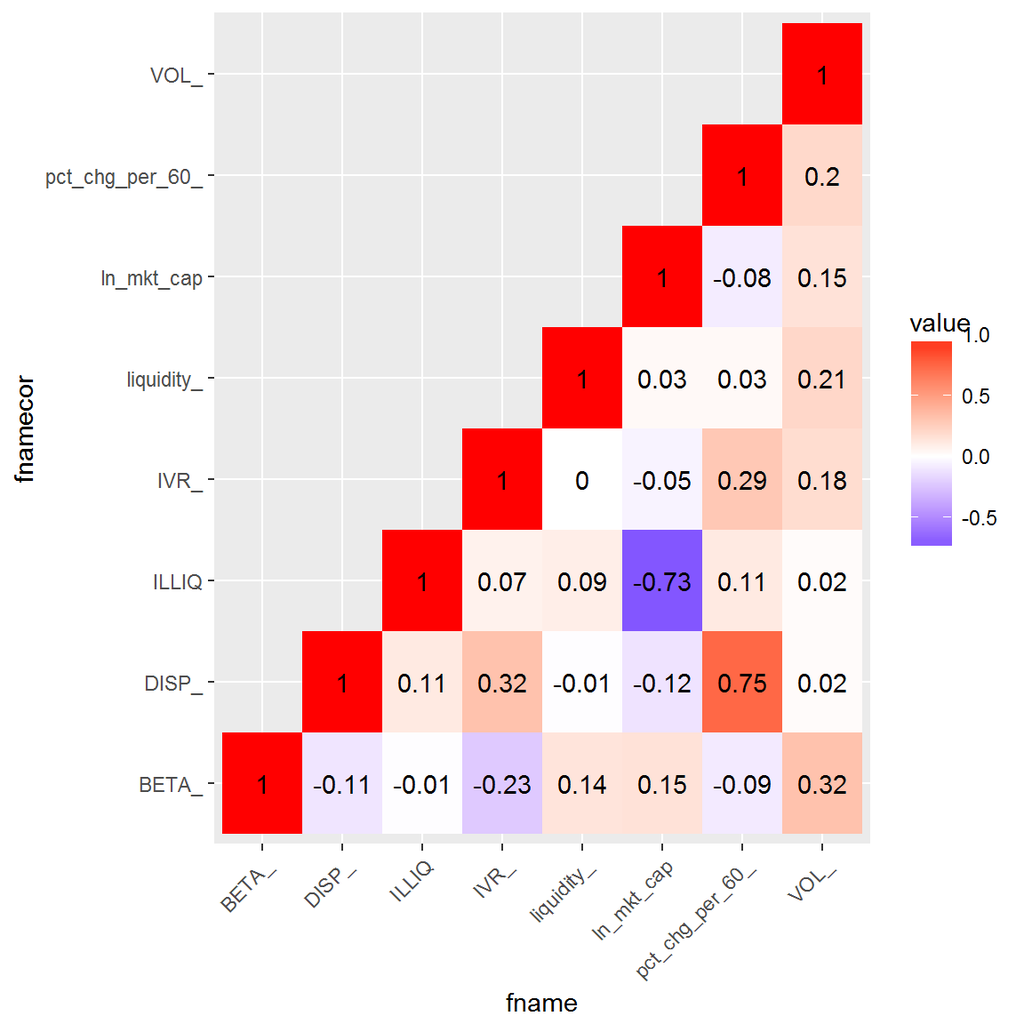

```r
MF.chart.Fct_corr(mtsf)
```

行业市值标准化后因子的相关性图

```
## The guessed factorNames are: VOL_,IVR_,BETA_,liquidity_,ILLIQ,DISP_,pct_chg_per_60_,ln_mkt_cap.
```

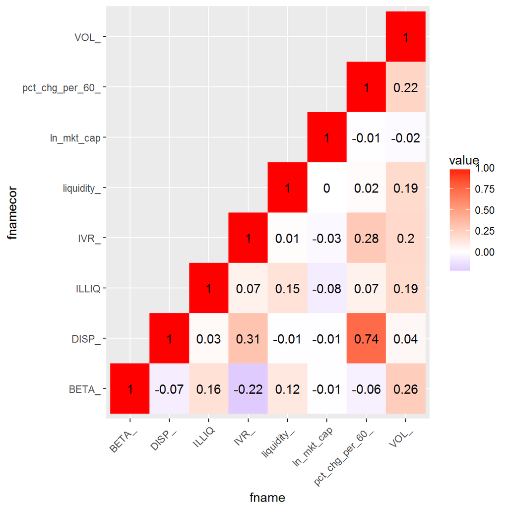

```r
MF.chart.Fct_corr(mtsfrefine)
```

## 9、SUMMARY

不同因子不同refine方式下因子IC和分组收益统计表

```r
kable(tablestats,digits = 2)
```

| factorName | refinePar | IC_mean | IC_std | IC_IR | IC_t | IC_p | IC_hitRatio | IC_annu | Annualized.Return | Annualized.StdDev | Annualized.Sharpe.Rf.0.. | HitRatio | Worst.Drawdown | Annualized.Turnover | Annualized.Return..fee.cut. | Beta | Size |
| --- | --- | --- | --- | --- | --- | --- | --- | --- | --- | --- | --- | --- | --- | --- | --- | --- | --- |
| VOL_ | scale | 0.03 | 0.17 | 0.18 | 2.23 | 0.03 | 0.63 | 0.10 | 0.08 | 0.18 | 0.48 | 0.63 | 0.30 | 3.79 | 0.08 | -0.28 | 263.36 |
| VOL_ | scale_ind | 0.03 | 0.13 | 0.23 | 2.88 | 0.00 | 0.62 | 0.11 | 0.09 | 0.14 | 0.64 | 0.62 | 0.23 | 4.03 | 0.09 | -0.23 | 200.99 |
| VOL_ | scale_indfct | 0.03 | 0.12 | 0.28 | 3.50 | 0.00 | 0.64 | 0.11 | 0.10 | 0.12 | 0.80 | 0.64 | 0.21 | 4.27 | 0.10 | -0.20 | 178.62 |
| VOL_ | reg_indfct | 0.04 | 0.12 | 0.31 | 3.90 | 0.00 | 0.64 | 0.13 | 0.11 | 0.13 | 0.86 | 0.63 | 0.17 | 4.02 | 0.11 | -0.21 | 72.76 |
| IVR_ | scale | 0.06 | 0.08 | 0.70 | 8.74 | 0.00 | 0.71 | 0.20 | 0.24 | 0.09 | 2.60 | 0.72 | 0.05 | 8.26 | 0.24 | 0.06 | 83.42 |
| IVR_ | scale_ind | 0.06 | 0.07 | 0.86 | 10.69 | 0.00 | 0.81 | 0.20 | 0.23 | 0.08 | 3.05 | 0.81 | 0.04 | 8.35 | 0.23 | 0.06 | -13.00 |
| IVR_ | scale_indfct | 0.05 | 0.06 | 0.96 | 11.96 | 0.00 | 0.83 | 0.18 | 0.22 | 0.06 | 3.40 | 0.85 | 0.03 | 8.43 | 0.22 | 0.04 | 1.19 |
| IVR_ | reg_indfct | 0.06 | 0.06 | 0.95 | 11.79 | 0.00 | 0.85 | 0.19 | 0.24 | 0.07 | 3.41 | 0.86 | 0.03 | 8.36 | 0.24 | 0.04 | 29.88 |
| BETA_ | scale | 0.01 | 0.14 | 0.05 | 0.58 | 0.56 | 0.54 | 0.02 | 0.02 | 0.14 | 0.11 | 0.52 | 0.30 | 2.23 | 0.02 | -0.19 | 229.42 |
| BETA_ | scale_ind | 0.00 | 0.11 | 0.01 | 0.13 | 0.89 | 0.54 | 0.00 | 0.00 | 0.12 | -0.01 | 0.52 | 0.35 | 2.42 | 0.00 | -0.16 | 211.82 |
| BETA_ | scale_indfct | 0.00 | 0.09 | 0.04 | 0.47 | 0.64 | 0.56 | 0.01 | 0.01 | 0.10 | 0.06 | 0.55 | 0.27 | 2.73 | 0.01 | -0.13 | 182.80 |
| BETA_ | reg_indfct | 0.00 | 0.09 | 0.05 | 0.67 | 0.50 | 0.57 | 0.02 | 0.01 | 0.10 | 0.11 | 0.55 | 0.22 | 2.39 | 0.01 | -0.14 | 95.77 |
| liquidity_ | scale | 0.01 | 0.08 | 0.16 | 1.97 | 0.05 | 0.57 | 0.04 | 0.04 | 0.08 | 0.48 | 0.56 | 0.25 | 7.63 | 0.04 | -0.08 | 26.93 |
| liquidity_ | scale_ind | 0.01 | 0.06 | 0.22 | 2.75 | 0.01 | 0.63 | 0.04 | 0.04 | 0.06 | 0.75 | 0.60 | 0.13 | 7.78 | 0.04 | -0.06 | 14.40 |
| liquidity_ | scale_indfct | 0.01 | 0.06 | 0.25 | 3.05 | 0.00 | 0.59 | 0.05 | 0.05 | 0.06 | 0.80 | 0.59 | 0.15 | 7.86 | 0.05 | -0.05 | 8.81 |
| liquidity_ | reg_indfct | 0.01 | 0.06 | 0.24 | 2.99 | 0.00 | 0.59 | 0.05 | 0.05 | 0.06 | 0.84 | 0.58 | 0.16 | 7.76 | 0.05 | -0.04 | -9.78 |
| ILLIQ | scale | 0.07 | 0.16 | 0.41 | 5.05 | 0.00 | 0.68 | 0.23 | 0.25 | 0.19 | 1.32 | 0.69 | 0.23 | 3.31 | 0.25 | 0.12 | -443.58 |
| ILLIQ | scale_ind | 0.06 | 0.13 | 0.45 | 5.62 | 0.00 | 0.72 | 0.21 | 0.23 | 0.16 | 1.50 | 0.71 | 0.19 | 3.52 | 0.23 | 0.11 | -250.14 |
| ILLIQ | scale_indfct | 0.05 | 0.09 | 0.58 | 7.26 | 0.00 | 0.75 | 0.18 | 0.20 | 0.10 | 1.88 | 0.76 | 0.10 | 4.45 | 0.20 | 0.02 | -189.28 |
| ILLIQ | reg_indfct | 0.05 | 0.09 | 0.51 | 6.40 | 0.00 | 0.70 | 0.16 | 0.16 | 0.10 | 1.58 | 0.68 | 0.15 | 4.36 | 0.16 | -0.08 | 197.72 |
| DISP_ | scale | 0.06 | 0.17 | 0.33 | 4.16 | 0.00 | 0.62 | 0.20 | 0.20 | 0.18 | 1.08 | 0.60 | 0.19 | 7.14 | 0.20 | 0.11 | -54.96 |
| DISP_ | scale_ind | 0.06 | 0.14 | 0.41 | 5.11 | 0.00 | 0.65 | 0.20 | 0.21 | 0.16 | 1.34 | 0.66 | 0.17 | 7.22 | 0.21 | 0.11 | -34.69 |
| DISP_ | scale_indfct | 0.06 | 0.12 | 0.45 | 5.63 | 0.00 | 0.65 | 0.19 | 0.20 | 0.14 | 1.51 | 0.68 | 0.14 | 7.29 | 0.20 | 0.10 | -23.67 |
| DISP_ | reg_indfct | 0.06 | 0.12 | 0.47 | 5.90 | 0.00 | 0.66 | 0.20 | 0.21 | 0.13 | 1.57 | 0.68 | 0.12 | 7.19 | 0.21 | 0.09 | 37.89 |
| pct_chg_per_60_ | scale | 0.05 | 0.16 | 0.33 | 4.05 | 0.00 | 0.63 | 0.18 | 0.16 | 0.18 | 0.93 | 0.61 | 0.22 | 6.23 | 0.16 | 0.07 | -18.17 |
| pct_chg_per_60_ | scale_ind | 0.05 | 0.13 | 0.39 | 4.83 | 0.00 | 0.70 | 0.18 | 0.18 | 0.15 | 1.20 | 0.69 | 0.19 | 6.39 | 0.18 | 0.08 | -9.48 |
| pct_chg_per_60_ | scale_indfct | 0.05 | 0.12 | 0.42 | 5.24 | 0.00 | 0.68 | 0.17 | 0.18 | 0.13 | 1.30 | 0.69 | 0.15 | 6.48 | 0.18 | 0.06 | -1.54 |
| pct_chg_per_60_ | reg_indfct | 0.05 | 0.12 | 0.45 | 5.64 | 0.00 | 0.69 | 0.18 | 0.18 | 0.13 | 1.37 | 0.70 | 0.15 | 6.29 | 0.18 | 0.06 | 39.03 |